# Estadistica Multidimencional

Analisis de homicidios

Angelo Alejandro Ibañez Hernandez 20212020007 Alejandro Gomez Moyano 20222020073 Juan David Córdoba Aguirre 20211020097 Oscar Santiago Duran Benitez 20212020080

24/03/2026

# 1 PARTE 1 - CARGA Y RECONOCIMIENTO

## 1.1 1. Cargar el dataset:

```r
homicidios <- read.csv("Homicidios.csv",
                       sep = ";",
                       fileEncoding = "Latin1",
                      check.names = TRUE)

# --- Corrección de caracteres corruptos por encoding ---
corrupcion_map <- list(
  list(p = "\u00b5", r = "A"),   # µ → A
  list(p = "\u00d6", r = "I"),   # Ö → I
  list(p = "\u00e1", r = "O"),   # á → O
  list(p = "\u00e9", r = "U"),   # é → U
  list(p = "\u00a5", r = "N"),   # ¥ → N
  list(p = "\u00a1", r = "i"),   # ¡ → i
  list(p = "\u00a2", r = "o"),   # ¢ → o
  list(p = "\u00ff", r = ""),    # ÿ → (eliminar)
  list(p = "\x82",   r = "E"),   # Miércoles corrupto → Miercoles
  list(p = "\xa0",   r = "A")    # Sábado corrupto → Sabado
)

# Función para aplicar todas las sustituciones a un texto
fix_corrupcion <- function(x) {
  for (entry in corrupcion_map) {
    x <- gsub(entry$p, entry$r, x, fixed = TRUE, useBytes = TRUE)
  }
  Encoding(x) <- "UTF-8"
  return(x)
}

# Corregir nombres de columnas
names(homicidios) <- fix_corrupcion(names(homicidios))

# Corregir valores en todas las columnas de tipo caracter
cols_char <- sapply(homicidios, is.character)
homicidios[cols_char] <- lapply(homicidios[cols_char], fix_corrupcion)

# Corregir nombres de algunas columnas
library(dplyr)

homicidios <- homicidios %>%
  rename(Dia = D.a,
         Pais_Nacimiento = Pa.s.de.nacimiento,
         Profesion = Profesi.n,
         Clase_de_sitio = Clase.de.sitio,
         Arma_empleada = Arma.empleada,
         Movil_agresor = M.vil.Agresor,
         Movil_victima = M.vil.Victima,
         Estado_civil  = Estado.civil,
         Clase_de_empleado = Clase.de.empleado,
         Codigo_DANE = C.digo.DANE
         )
```

## 1.2 2. Mostrar:

### 1.2.1 2.1 head ()

```r
head(homicidios)
```

|  | Fecha | Departamento | Municipio | Dia | Hora | Barrio | Zona | Clase_de_sitio | Arma_empleada | Movil_agresor | Movil_victima | Edad | Sexo | Estado_civil | Pais_Nacimiento | Clase_de_empleado | Profesion | Escolaridad | Codigo_DANE | Cantidad |
| --- | --- | --- | --- | --- | --- | --- | --- | --- | --- | --- | --- | --- | --- | --- | --- | --- | --- | --- | --- | --- |
| 1 | 1/01/2017 | AMAZONAS | LETICIA (CT) | Domingo | 15:05:00 | KILOMETRO 11 | RURAL | CARRETERA | ARMA BLANCA / CORTOPUNZANTE | PASAJERO MOTOCICLETA | PASAJERO MOTOCICLETA | 20 | MASCULINO | SOLTERO | COLOMBIA | EMPLEADO PARTICULAR | S.D. | SECUNDARIA | 91,001,000 | 1 |
| 2 | 1/01/2017 | ANTIOQUIA | BETANIA | Domingo | 21:20:00 | LA CUMBRE | URBANA | VIAS PUBLICAS | ARMA DE FUEGO | A PIE | A PIE | 21 | MASCULINO | SOLTERO | COLOMBIA | INDEPENDIENTE | S.D. | PRIMARIA | 5,091,000 | 1 |
| 3 | 1/01/2017 | ANTIOQUIA | COPACABANA | Domingo | 4:48:00 | MACHADO | URBANA | DENTRO DE LA VIVIENDA | ARMA BLANCA / CORTOPUNZANTE | A PIE | A PIE | 22 | MASCULINO | UNION LIBRE | COLOMBIA | INDEPENDIENTE | S.D. | SECUNDARIA | 5,212,000 | 1 |
| 4 | 1/01/2017 | ANTIOQUIA | EB\u0090JICO | Domingo | 5:00:00 | SAGUA | RURAL | FINCAS Y SIMILARES | ARMA DE FUEGO | A PIE | A PIE | 46 | MASCULINO | SOLTERO | COLOMBIA | INDEPENDIENTE | S.D. | SECUNDARIA | 5,240,000 | 1 |
| 5 | 1/01/2017 | ANTIOQUIA | EL BAGRE | Domingo | 6:30:00 | LAS BRISAS | URBANA | VIAS PUBLICAS | ARMA BLANCA / CORTOPUNZANTE | A PIE | A PIE | 37 | MASCULINO | UNION LIBRE | COLOMBIA | INDEPENDIENTE | S.D. | PRIMARIA | 5,250,000 | 1 |
| 6 | 1/01/2017 | ANTIOQUIA | ITUANGO | Domingo | 6:40:00 | PENITAS | URBANA | VIAS PUBLICAS | ARMA BLANCA / CORTOPUNZANTE | A PIE | A PIE | 41 | MASCULINO | DIVORCIADO | COLOMBIA | AGRICULTOR | S.D. | PRIMARIA | 5,361,000 | 1 |

### 1.2.2 2.2 str()

```r
str(homicidios)
```

[output not shown]

### 1.2.3 2.3 summary

```r
summary(homicidios)
```

[output not shown]

## 1.3 3. Identificar:

### 1.3.1 Número de variables

En total, el dataset contiene 20 variables. Esto se puede evidenciar gracias a `str(homicidios)` distribuidas en la siguiente forma.

#### 1.3.1.1 Variables cualitativas

18 variables cualitativas:

- Departamento
- Municipio
- Dia
- Barrio
- Zona
- Clase de sitio
- Arma empleada
- Movil Agresor
- Movil Victima
- Sexo
- Estado civil
- Pais de nacimiento
- Clase de empleo
- Profesión
- Escolaridad

#### 1.3.1.2 Variables cuantitativas

2 variables cuantitativas

- Edad
- Cantidad

## 1.4 4. Explicar:

### 1.4.1 ¿Qué tipo de información contiene el dataset?

En el dataset se encuentra dos tipos de informacion:

- informacion sobre el lugar y el dia donde se cometio el asesinato, el arma que se uso y la forma de movilizarce del asesino.
- informacion de la victima y la manera en la que se estaba movilizando.

# 2 PARTE 2 - ANÁLISIS UNIVARIADO

## 2.1 Edad

### 2.1.1 1. Tipo de variable

La edad es una variable cuantitativa.

### 2.1.2 2. Gráfico

```r
# Convertir a numérico (esto generará NAs donde dice "S.D.")
homicidios$Edad <- as.numeric(as.character(homicidios$Edad))

hist(homicidios$Edad,
     main = "Histograma de Edad",
     xlab = "Edad",
     ylab = "Frecuencia",
     col = "steelblue")

boxplot(homicidios$Edad, horizontal = FALSE)
```

[output not shown]

### 2.1.3 3. Interpretación

Para la variable edad, se puede observar en el histograma que puede tener una distribución similar a la normal aunque desplazada hacia la izquierda.

Se puede evidenciar que la mayor parte de los homicidios ocurren en el rango entre los 20 y 40 años de edad aproximadamente, es decir que los homicidios reportados se concentran en la población más joven.

## 2.2 Departamento

### 2.2.1 1. Tipo de variable

Departamento es una variable cualitativa nominal.

### 2.2.2 2. Grafico

```r
freq_depto <- table(homicidios$Departamento)
freq_depto_sorted <- sort(freq_depto, decreasing = TRUE)

names(freq_depto_sorted) <- iconv(names(freq_depto_sorted), to = "ASCII//TRANSLIT")

barplot(freq_depto_sorted,
        main = "Frecuencia de Homicidios por Departamento",
        xlab = "Departamento",
        ylab = "Frecuencia",
        col = "steelblue",
        las = 2,
        cex.names = 0.6)
```

[output not shown]

### 2.2.3 3. Interpretacion

Para la variable Departamento, se observa en el diagrama de barras que los homicidios no se distribuyen de manera uniforme a lo largo del territorio nacional. Existen departamentos con una frecuencia de homicidios considerablemente mayor, lo que indica una concentracion geografica de la violencia. Los departamentos con mayor cantidad de casos corresponden a aquellos con mayor densidad poblacional y mayor actividad de conflicto armado o criminalidad.

## 2.3 Zona

### 2.3.1 1. Tipo de variable

Zona es una variable cualitativa nominal dicotomica (urbana/rural).

### 2.3.2 2. Grafico

```r
freq_zona <- table(homicidios$Zona)

barplot(freq_zona,
        main = "Frecuencia de Homicidios por Zona",
        xlab = "Zona",
        ylab = "Frecuencia",
        col = "steelblue")
```

[output not shown]

### 2.3.3 3. Interpretacion

Para la variable Zona, se observa en el diagrama de barras que la mayoria de los homicidios se concentran en la zona urbana, superando ampliamente a la zona rural. Esto puede estar relacionado con la mayor densidad poblacional en areas urbanas, asi como con factores asociados a la criminalidad urbana como el sicariato, las riñas y el crimen organizado.

## 2.4 Arma Empleada

### 2.4.1 1. Tipo de variable

Arma empleada es una variable cualitativa nominal.

### 2.4.2 2. Grafico

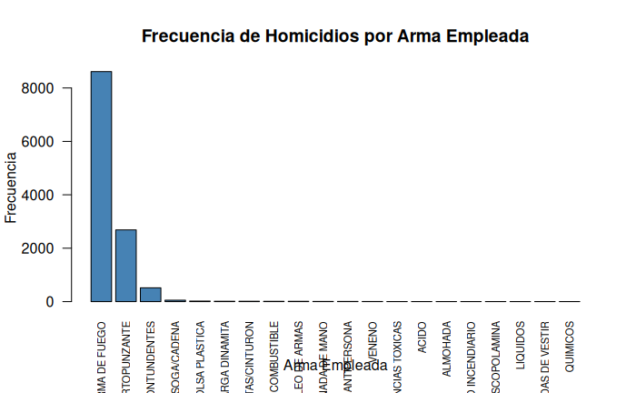

```r
freq_arma <- table(homicidios$Arma_empleada)
freq_arma_sorted <- sort(freq_arma, decreasing = TRUE)

barplot(freq_arma_sorted,
        main = "Frecuencia de Homicidios por Arma Empleada",
        xlab = "Arma Empleada",
        ylab = "Frecuencia",
        col = "steelblue",
        las = 2,
        cex.names = 0.7)
```

### 2.4.3 3. Interpretacion

Para la variable Arma empleada, se puede observar en el diagrama de barras que el arma de fuego es el medio mas utilizado en los homicidios, seguida por el arma blanca o cortopunzante. Los demas tipos de armas presentan frecuencias significativamente menores. Esto evidencia que los homicidios en Colombia estan asociados predominantemente al uso de armas de fuego, lo cual puede estar vinculado a la disponibilidad y circulacion ilegal de este tipo de armamento.

## 2.5 Municipio

### 2.5.1 1. Tipo de variable

Municipio es una variable cualitativa nominal.

### 2.5.2 2. Grafico

```r
freq_municipio <- table(homicidios$Municipio)
freq_municipio_sorted <- sort(freq_municipio, decreasing = TRUE)

names(freq_municipio_sorted) <- iconv(names(freq_municipio_sorted), to = "ASCII//TRANSLIT")

barplot(head(freq_municipio_sorted, 20),
        main = "Top 20 Municipios con Mayor Frecuencia de Homicidios",
        xlab = "Municipio",
        ylab = "Frecuencia",
        col = "steelblue",
        las = 2,
        cex.names = 0.6)
```

[output not shown]

### 2.5.3 3. Interpretacion

Para la variable Municipio, se observa en el diagrama de barras (limitado al top 20 para mayor legibilidad) que los homicidios se concentran fuertemente en unos pocos municipios, principalmente las grandes ciudades del pais. La distribucion es altamente asimetrica, con unas pocas ciudades capitales acumulando la mayor cantidad de casos, mientras que la gran mayoria de municipios presentan frecuencias bajas. Esto refleja la concentracion de la violencia homicida en los principales centros urbanos.

## 2.6 Profesion

### 2.6.1 1. Tipo de variable

Profesion es una variable cualitativa nominal.

### 2.6.2 2. Grafico

```r
freq_profesion <- table(homicidios$Profesion)
freq_profesion_sorted <- sort(freq_profesion, decreasing = TRUE)

names(freq_profesion_sorted) <- iconv(names(freq_profesion_sorted), to = "ASCII//TRANSLIT")

barplot(head(freq_profesion_sorted, 15),
        main = "Frecuencia de Homicidios por Profesion",
        xlab = "Profesion",
        ylab = "Frecuencia",
        col = "steelblue",
        las = 2,
        cex.names = 0.6)
```

[output not shown]

### 2.6.3 3. Interpretacion

Para la variable Profesion, se observa en el diagrama de barras que ciertas profesiones u ocupaciones presentan una frecuencia de homicidios notoriamente mayor que otras. Las victimas se concentran en determinados oficios, lo cual puede estar asociado a factores de exposicion y riesgo propios de dichas actividades laborales. Existe tambien una alta frecuencia de registros sin informacion, lo que puede afectar la completitud del analisis.

## 2.7 Escolaridad

### 2.7.1 1. Tipo de variable

Escolaridad es una variable cualitativa ordinal.

### 2.7.2 2. Grafico

```r
freq_escolaridad <- table(homicidios$Escolaridad)
freq_escolaridad_sorted <- sort(freq_escolaridad, decreasing = TRUE)

barplot(freq_escolaridad_sorted,
        main = "Frecuencia de Homicidios por Escolaridad",
        xlab = "Escolaridad",
        ylab = "Frecuencia",
        col = "steelblue",
        las = 2,
        cex.names = 0.7)
```

[output not shown]

### 2.7.3 3. Interpretacion

Para la variable Escolaridad, se observa en el diagrama de barras que la mayor parte de las victimas de homicidio corresponden a niveles de escolaridad bajos o medios, como primaria y secundaria. Los niveles educativos superiores (tecnico, universitario, posgrado) presentan frecuencias considerablemente menores. Esto sugiere que las victimas de homicidio tienden a pertenecer a sectores de la poblacion con menor nivel educativo, lo cual puede estar asociado a condiciones socioeconomicas de vulnerabilidad.

## 2.8 Sexo

### 2.8.1 1. Tipo de variable

Sexo es una variable cualitativa nominal dicotómica (Femenino/Masculino).

### 2.8.2 2. Gráfico

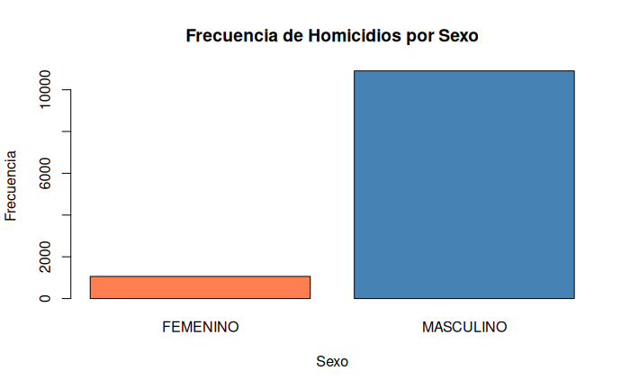

```r
freq_sexo <- table(homicidios$Sexo)
barplot(freq_sexo,
        main = "Frecuencia de Homicidios por Sexo",
        xlab = "Sexo",
        ylab = "Frecuencia",
        col = c("coral", "steelblue"))
```

### 2.8.3 3. Interpretacion

La distribución por sexo revela una marcada asimetría: aproximadamente el 90% de las víctimas son de sexo masculino, mientras que el 10% son de sexo femenino. Este patrón sugiere que los homicidios en Colombia están fuertemente asociados a dinámicas de violencia donde los hombres tienen mayor exposición, incluyendo crimen organizado, sicariato y violencia vinculada a pandillas.

## 2.9 Dia

### 2.9.1 1. Tipo de variable

Día es una variable cualitativa nominal cíclica (Lunes a Domingo).

### 2.9.2 2. Gráfico

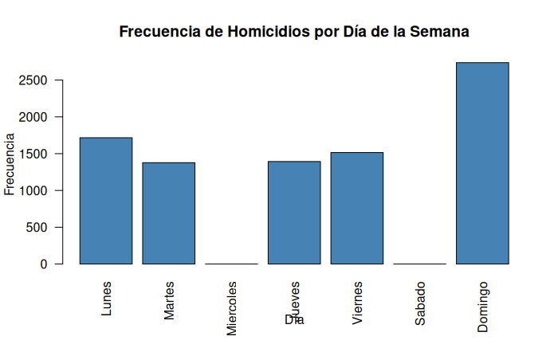

```r
dias_orden <- c("Lunes", "Martes", "Miercoles", "Jueves", "Viernes", "Sabado", "Domingo")
homicidios$Dia <- factor(homicidios$Dia, levels = dias_orden)

barplot(table(homicidios$Dia),
        main = "Frecuencia de Homicidios por Día de la Semana",
        xlab = "Día",
        ylab = "Frecuencia",
        col = "steelblue",
        las = 2)
```

# 3 PARTE 3 - ANÁLISIS BIVARIADO

## 3.1 Ejercicio 1: Edad vs Sexo

### 3.1.1 Tipo: numérico vs categórico

### 3.1.2 Gráfico: boxplot

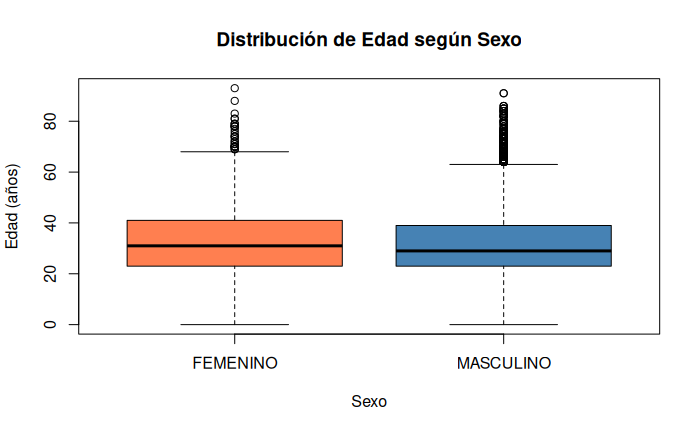

```r
boxplot(Edad ~ Sexo, data = homicidios,
        main = "Distribución de Edad según Sexo",
        xlab = "Sexo",
        ylab = "Edad (años)",
        col = c("coral", "steelblue"))
```

```r
homicidios %>%
  group_by(Sexo) %>%
  summarise(
    Media = mean(Edad, na.rm = TRUE),
    Mediana = median(Edad, na.rm = TRUE),
    Q1 = quantile(Edad, 0.25, na.rm = TRUE),
    Q3 = quantile(Edad, 0.75, na.rm = TRUE)
  )
```

[output not shown]

## 3.2 Ejercicio 2: Arma empleada vs Zona

### 3.2.1 Tipo: categórico vs categórico

### 3.2.2 Gráfico: barras agrupadas / tabla cruzada

```r
library(ggplot2)
library(dplyr)

tabla_arma_zona <- table(homicidios$Arma_empleada, homicidios$Zona)
prop.table(tabla_arma_zona, margin = 2) * 100
```

```
                                           RURAL      URBANA
  ACIDO                               0.00000000  0.01204819
  ALMOHADA                            0.00000000  0.01204819
  ARMA BLANCA / CORTOPUNZANTE        19.23601637 23.87951807
  ARMA DE FUEGO                      74.35197817 70.93975904
  ARTEFACTO EXPLOSIVO/CARGA DINAMITA  0.24556617  0.06024096
  ARTEFACTO INCENDIARIO               0.02728513  0.00000000
  BOLSA PLASTICA                      0.13642565  0.19277108
  CINTAS/CINTURON                     0.13642565  0.08433735
  COMBUSTIBLE                         0.05457026  0.09638554
  CONTUNDENTES                        4.74761255  4.13253012
  CUERDA/SOGA/CADENA                  0.51841746  0.40963855
  ESCOPOLAMINA                        0.00000000  0.01204819
  GRANADA DE MANO                     0.08185539  0.04819277
  LIQUIDOS                            0.00000000  0.01204819
  MINA ANTIPERSONA                    0.19099591  0.00000000
  PRENDAS DE VESTIR                   0.00000000  0.01204819
  QUIMICOS                            0.02728513  0.00000000
  SIN EMPLEO DE ARMAS                 0.08185539  0.08433735
  SUSTANCIAS TOXICAS                  0.05457026  0.00000000
  VENENO                              0.10914052  0.01204819
```

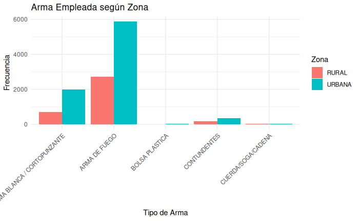

```r
arma_zona_df <- homicidios %>%
  filter(Arma_empleada %in% names(head(sort(table(Arma_empleada), decreasing = TRUE), 5)))

ggplot(arma_zona_df, aes(x = Arma_empleada, fill = Zona)) +
  geom_bar(position = "dodge") +
  labs(title = "Arma Empleada según Zona",
       x = "Tipo de Arma",
       y = "Frecuencia") +
  theme_minimal() +
  theme(axis.text.x = element_text(angle = 45, hjust = 1))
```

### 3.2.4 4. Conclusión

La violencia con armas presenta una incidencia considerablemente mayor en las zonas urbanas, lo cual puede atribuirse, en gran medida, a la alta densidad poblacional que caracteriza estos entornos.

## 3.3 Ejercicio 3: Edad vs Tipo de arma

### 3.3.1 Tipo: numerico vs categórico

### 3.3.2 Gráfico: boxplot

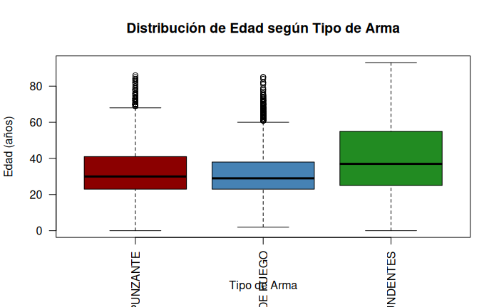

```r
arma_edad_df <- homicidios %>%
  filter(Arma_empleada %in% c("ARMA DE FUEGO", "ARMA BLANCA / CORTOPUNZANTE", "CONTUNDENTES"))

boxplot(Edad ~ Arma_empleada, data = arma_edad_df,
        main = "Distribución de Edad según Tipo de Arma",
        xlab = "Tipo de Arma",
        ylab = "Edad (años)",
        col = c("darkred", "steelblue", "forestgreen"),
        las = 2)
```

### 3.3.3 3. Interpretacion

Las víctimas de arma de fuego presentan la mediana de edad más baja, seguidas por arma blanca y contundentes. El rango intercuartílico es más estrecho para arma de fuego, indicando concentración en adultos jóvenes.

### 3.3.4 4. Conclusión

Existe una relación inversa entre la letalidad del arma y la edad de la víctima: armas más mortal, se usan contra víctimas más jóvenes, probablemente en contextos de grupos criminales organizados; mientras que armas más accesibles (blanca, contundentes) aparecen en homicidios con víctimas de mayor edad, probablemente riñas y conflictos interpersonales.

## 3.4 Ejercicio 4: Departamento vs Cantidad

### 3.4.1 Tipo: numerico vs categórico

### 3.4.2 Gráfico: barras

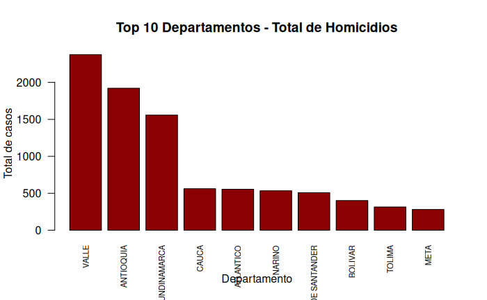

```r
depto_cantidad <- homicidios %>%
  group_by(Departamento) %>%
  summarise(Total_Casos = sum(Cantidad, na.rm = TRUE)) %>%
  arrange(desc(Total_Casos))

barplot(height = head(depto_cantidad$Total_Casos, 10),
        names.arg = head(depto_cantidad$Departamento, 10),
        main = "Top 10 Departamentos - Total de Homicidios",
        xlab = "Departamento",
        ylab = "Total de casos",
        col = "darkred",
        las = 2,
        cex.names = 0.7)
```

### 3.4.3 3. Interpretacion

Los departamentos de Valle, Antioquia y Cundinamarca concentran la mayor cantidad de homicidios, destacándose significativamente por encima del resto. Esto sugiere una alta incidencia de este fenómeno en estas regiones en comparación con los demás departamentos analizados.

### 3.4.4 4. Conclusión

Los homicidios se concentran geográficamente en los departamentos más poblados y con mayores centros urbanos, aunque esto no necesariamente implica tasas más altas. La concentración en Antioquia y Valle refleja la persistencia de dinámicas de violencia en Medellín y Cali.

# 4 PARTE 4 - ANÁLISIS MULTIVARIADO

## 4.1 1. Matriz de correlación

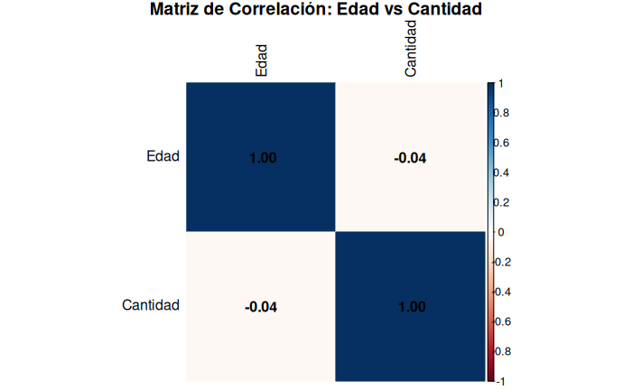

```r
data_num <- na.omit(homicidios[, c("Edad", "Cantidad")])
matriz_cor <- cor(data_num)
library(corrplot)
corrplot(matriz_cor,
         method = "color",
         addCoef.col = "black",
         tl.col = "black",
         title = "Matriz de Correlación: Edad vs Cantidad",
         mar = c(0,0,1,0))
```

### 4.1.1 ¿Existe relación?

No. Cómo se puede evidenciar en la matriz, la correlación entre `Edad` y `Cantidad` es de -0.04, muy cercano a cero, por lo tanto no se puede decir que haya correlación ni que una describa a la otra. Son independientes. Esto principalmente se debe a que el valor de `Cantidad` es 1 para cada prácticamente todos los registros, por lo que no se puede establecer una relación entre la edad y la cantidad.

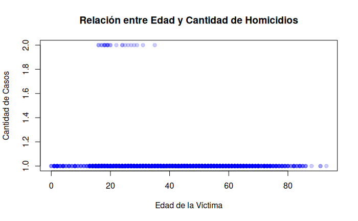

```r
data_grafica <- na.omit(homicidios[, c("Edad", "Cantidad")])

plot(x = data_grafica$Edad, y = data_grafica$Cantidad,
     main = "Relación entre Edad y Cantidad de Homicidios",
     xlab = "Edad de la Víctima",
     ylab = "Cantidad de Casos",
     pch = 19,      # Tipo de punto (sólido)
     col = rgb(0, 0, 1, 0.2))
```

Está gráfica de dispersión es muy útil para entender por qué no hay relación. Al crecer la edad, no crece ni disminuye la cantidad, de hecho es una linea recta que se queda en 1 (exceptuando algunos valores anomalos), por lo que es imposible saber cual es la edad dada la cantidad.

### 4.1.2 ¿Es fuerte o débil?

Más que fuerte o débil, es prácticamente nula. No hay relación lineal entre estas dos variables.

## 4.2 2. Análisis combinado

Se analizarán: Zona + Arma + Departamento

### 4.2.1 Facetas

Para asegurar que la gráfica sea legible, se analizarán solo el top 6 de departamentos con más homicidios.

```r
library(ggplot2)
library(dplyr)

# Filtrar el Top 6 de departamentos para que el gráfico sea legible
top_deptos <- homicidios %>%
  group_by(Departamento) %>%
  tally(sort = TRUE) %>%
  top_n(6) %>%
  pull(Departamento)

data_filtrada <- homicidios %>% filter(Departamento %in% top_deptos)

ggplot(data_filtrada, aes(y = Arma_empleada, fill = Zona)) +
  geom_bar(position = "dodge") +
  facet_wrap(~Departamento) +
  labs(title = "Armas empleadas por Zona en los principales Departamentos",
       x = "Cantidad de Homicidios",
       y = "Arma") +
  theme_minimal() +
  theme(legend.position = "bottom")
```

[output not shown]

### 4.2.2 ¿Se observan patrones?

El `arma de fuego` es predominante en todos los departamentos analizados sin excepción, así como el `arma blanca / cortopunzante` se mantiene en segundo lugar en todos.

Estas mismas armas también suelen dominar en zonas urbanas más que rurales en la mayoría de departamentos. Sin embargo esto podría deberse a que en aquellos departamentos puede haber mayor población urbana que rural y por lo tanto podría haber más casos.

Se observa también como, en algunos departamentos como Antioquia, hay predominancia de zonas urbanas, mientras que en otros como Nariño, predominan las zonas rurales.

### 4.2.3 ¿Hay grupos?

Está el grupo urbano, en el cual los homicidios efectuados con cualquier arma son mayormente cometidos en zona urbana. Este grupo está constituido por: * Antioquia * Atlántico * Cundinamarca * Valle

También está el grupo rural, en el cual los homicidios efectuados con cualquier arma son mayormente en zona rural Este grupo está consittuido por: * Cauca * Nariño

### 4.2.4 ¿Qué variables parecen estar relacionadas?

Parece que el uso de armas de fuego podría estar relacionado con el tipo de zona del departamento. Se puede observar como en zonas urbanas el uso de las armas de fuego tiende a ser significativamente mayor que en zonas rurales, teniendo casos como en el Valle, Cundinamarca y Atlántico que las armas de fuego multiplican varias veces su uso en zona urbana frente a la rural.

# 5 PARTE 5 - CONCLUSIONES

## 5.1 Conclusión 1: Perfil demográfico de la víctima

Los homicidios en Colombia afectan predominantemente a hombres jóvenes (20-35 años), solteros, con nivel educativo básico (primaria o secundaria). Este perfil sugiere victimización vinculada a dinámicas de violencia urbana, crimen organizado y situaciones de vulnerabilidad socioeconómica donde los jóvenes hombres tienen mayor exposición.

## 5.3 Conclusión 3: Instrumentos de violencia

El arma de fuego es el instrumento predominante en más del 60% de los casos, con mayor concentración en zonas urbanas y departamentos con presencia de criminalidad organizada. Su predominio está asociado a victimas más jóvenes, sugiriendo vinculación con pandillas y sicariato.

## 5.5 Conclusión 5: Interacción de variables

Existe una interacción significativa entre zona geográfica, departamento y tipo de arma. Los departamentos con mayor violencia organizada muestran similitudes en el uso de armas de fuego, mientras que en otros la zona (urbana/rural) diferencia el tipo de arma empleada, revelando patrones de violencia estructural versus violencia interpersonal.